# MarcosUeta_MT_Project_LearnerNotebook_FullCode_revD

## Problem Statement

### Business Context

Renewable energy sources play an increasingly important role in the global energy mix, as the effort to reduce the environmental impact of energy production increases.

Out of all the renewable energy alternatives, wind energy is one of the most developed technologies worldwide. The U.S Department of Energy has put together a guide to achieving operational efficiency using predictive maintenance practices.

Predictive maintenance uses sensor information and analysis methods to measure and predict degradation and future component capability. The idea behind predictive maintenance is that failure patterns are predictable and if component failure can be predicted accurately and the component is replaced before it fails, the costs of operation and maintenance will be much lower.

The sensors fitted across different machines involved in the process of energy generation collect data related to various environmental factors (temperature, humidity, wind speed, etc.) and additional features related to various parts of the wind turbine (gearbox, tower, blades, break, etc.).

## Objective

“ReneWind” is a company working on improving the machinery/processes involved in the production of wind energy using machine learning and has collected data of generator failure of wind turbines using sensors. They have shared a ciphered version of the data, as the data collected through sensors is confidential (the type of data collected varies with companies). Data has 40 predictors, 20000 observations in the training set and 5000 in the test set.

The objective is to build various classification models, tune them, and find the best one that will help identify failures so that the generators could be repaired before failing/breaking to reduce the overall maintenance cost. The nature of predictions made by the classification model will translate as follows:

- True positives (TP) are failures correctly predicted by the model. These will result in repairing costs.
- False negatives (FN) are real failures where there is no detection by the model. These will result in replacement costs.
- False positives (FP) are detections where there is no failure. These will result in inspection costs.

It is given that the cost of repairing a generator is much less than the cost of replacing it, and the cost of inspection is less than the cost of repair.

“1” in the target variables should be considered as “failure” and “0” represents “No failure”.

## Data Description

- The data provided is a transformed version of original data which was collected using sensors.
- Train.csv - To be used for training and tuning of models.
- Test.csv - To be used only for testing the performance of the final best model.
- Both the datasets consist of 40 predictor variables and 1 target variable

## Importing necessary libraries

```python
# To help with reading and manipulating data
import pandas as pd
import numpy as np

# To help with data visualization
%matplotlib inline
import matplotlib.pyplot as plt
import seaborn as sns

# To be used for missing value imputation
from sklearn.impute import SimpleImputer

# Oversampling and Undersampling
from imblearn.over_sampling import SMOTE
from imblearn.under_sampling import RandomUnderSampler

# To help with model building
from sklearn.linear_model import LogisticRegression
from sklearn.tree import DecisionTreeClassifier
from sklearn.ensemble import (
    AdaBoostClassifier,
    GradientBoostingClassifier,
    RandomForestClassifier,
    BaggingClassifier,
)
from xgboost import XGBClassifier

# To get different metric scores, and split data
from sklearn import metrics
from sklearn.model_selection import train_test_split, StratifiedKFold, cross_val_score
from sklearn.metrics import (
    f1_score,
    accuracy_score,
    recall_score,
    precision_score,
    confusion_matrix,
    roc_auc_score,
    ConfusionMatrixDisplay,
)

# To be used for data scaling and one hot encoding
from sklearn.preprocessing import StandardScaler, MinMaxScaler, OneHotEncoder

# To be used for tuning the model
from sklearn.model_selection import GridSearchCV, RandomizedSearchCV

# To be used for creating pipelines and personalizing them
from sklearn.pipeline import Pipeline
from sklearn.compose import ColumnTransformer

# To define maximum number of columns to be displayed in a dataframe
pd.set_option("display.max_columns", None)

# To supress scientific notations for a dataframe
pd.set_option("display.float_format", lambda x: "%.3f" % x)

# To supress warnings
import warnings

warnings.filterwarnings("ignore")

# This will help in making the Python code more structured automatically (good coding practice)
#%load_ext nb_black
```

## Loading the dataset

```python
from google.colab import files
uploaded = files.upload()
df_test = pd.read_csv("Test.csv")
df_train = pd.read_csv("Train.csv")
```

```
Saving Test.csv to Test.csv
Saving Train.csv to Train.csv
```

## Data Overview

- Observations
- Sanity checks

```python
print(df_test.shape)
print(df_train.shape)
```

```
(5000, 41)
(20000, 41)
```

- Dataset contains total of 25,000 observations and 41 features. The proportion train/test set is 4:1.

```python
print(df_train.info())
print(df_test.info())
```

```
<class 'pandas.core.frame.DataFrame'>
RangeIndex: 20000 entries, 0 to 19999
Data columns (total 41 columns):
 #   Column  Non-Null Count  Dtype
---  ------  --------------  -----
 0   V1      19982 non-null  float64
 1   V2      19982 non-null  float64
 2   V3      20000 non-null  float64
 3   V4      20000 non-null  float64
 4   V5      20000 non-null  float64
 5   V6      20000 non-null  float64
 6   V7      20000 non-null  float64
 7   V8      20000 non-null  float64
 8   V9      20000 non-null  float64
 9   V10     20000 non-null  float64
```

[output cut: 83 more lines]

- Total of 41 columns (40 features) and 25,000 observations in the dataframe;
- There are all continous variables (except Target);
- There are missing values in the first columns.

```python
df_train.describe(include="all").T
```

|  | count | mean | std | min | 25% | 50% | 75% | max |
| --- | --- | --- | --- | --- | --- | --- | --- | --- |
| V1 | 19982.000 | -0.272 | 3.442 | -11.876 | -2.737 | -0.748 | 1.840 | 15.493 |
| V2 | 19982.000 | 0.440 | 3.151 | -12.320 | -1.641 | 0.472 | 2.544 | 13.089 |
| V3 | 20000.000 | 2.485 | 3.389 | -10.708 | 0.207 | 2.256 | 4.566 | 17.091 |
| V4 | 20000.000 | -0.083 | 3.432 | -15.082 | -2.348 | -0.135 | 2.131 | 13.236 |
| V5 | 20000.000 | -0.054 | 2.105 | -8.603 | -1.536 | -0.102 | 1.340 | 8.134 |
| V6 | 20000.000 | -0.995 | 2.041 | -10.227 | -2.347 | -1.001 | 0.380 | 6.976 |
| V7 | 20000.000 | -0.879 | 1.762 | -7.950 | -2.031 | -0.917 | 0.224 | 8.006 |
| V8 | 20000.000 | -0.548 | 3.296 | -15.658 | -2.643 | -0.389 | 1.723 | 11.679 |
| V9 | 20000.000 | -0.017 | 2.161 | -8.596 | -1.495 | -0.068 | 1.409 | 8.138 |
| V10 | 20000.000 | -0.013 | 2.193 | -9.854 | -1.411 | 0.101 | 1.477 | 8.108 |
| V11 | 20000.000 | -1.895 | 3.124 | -14.832 | -3.922 | -1.921 | 0.119 | 11.826 |
| V12 | 20000.000 | 1.605 | 2.930 | -12.948 | -0.397 | 1.508 | 3.571 | 15.081 |
| V13 | 20000.000 | 1.580 | 2.875 | -13.228 | -0.224 | 1.637 | 3.460 | 15.420 |
| V14 | 20000.000 | -0.951 | 1.790 | -7.739 | -2.171 | -0.957 | 0.271 | 5.671 |
| V15 | 20000.000 | -2.415 | 3.355 | -16.417 | -4.415 | -2.383 | -0.359 | 12.246 |
| V16 | 20000.000 | -2.925 | 4.222 | -20.374 | -5.634 | -2.683 | -0.095 | 13.583 |
| V17 | 20000.000 | -0.134 | 3.345 | -14.091 | -2.216 | -0.015 | 2.069 | 16.756 |
| V18 | 20000.000 | 1.189 | 2.592 | -11.644 | -0.404 | 0.883 | 2.572 | 13.180 |
| V19 | 20000.000 | 1.182 | 3.397 | -13.492 | -1.050 | 1.279 | 3.493 | 13.238 |
| V20 | 20000.000 | 0.024 | 3.669 | -13.923 | -2.433 | 0.033 | 2.512 | 16.052 |
| V21 | 20000.000 | -3.611 | 3.568 | -17.956 | -5.930 | -3.533 | -1.266 | 13.840 |
| V22 | 20000.000 | 0.952 | 1.652 | -10.122 | -0.118 | 0.975 | 2.026 | 7.410 |
| V23 | 20000.000 | -0.366 | 4.032 | -14.866 | -3.099 | -0.262 | 2.452 | 14.459 |
| V24 | 20000.000 | 1.134 | 3.912 | -16.387 | -1.468 | 0.969 | 3.546 | 17.163 |
| V25 | 20000.000 | -0.002 | 2.017 | -8.228 | -1.365 | 0.025 | 1.397 | 8.223 |
| V26 | 20000.000 | 1.874 | 3.435 | -11.834 | -0.338 | 1.951 | 4.130 | 16.836 |
| V27 | 20000.000 | -0.612 | 4.369 | -14.905 | -3.652 | -0.885 | 2.189 | 17.560 |
| V28 | 20000.000 | -0.883 | 1.918 | -9.269 | -2.171 | -0.891 | 0.376 | 6.528 |
| V29 | 20000.000 | -0.986 | 2.684 | -12.579 | -2.787 | -1.176 | 0.630 | 10.722 |
| V30 | 20000.000 | -0.016 | 3.005 | -14.796 | -1.867 | 0.184 | 2.036 | 12.506 |
| V31 | 20000.000 | 0.487 | 3.461 | -13.723 | -1.818 | 0.490 | 2.731 | 17.255 |
| V32 | 20000.000 | 0.304 | 5.500 | -19.877 | -3.420 | 0.052 | 3.762 | 23.633 |
| V33 | 20000.000 | 0.050 | 3.575 | -16.898 | -2.243 | -0.066 | 2.255 | 16.692 |
| V34 | 20000.000 | -0.463 | 3.184 | -17.985 | -2.137 | -0.255 | 1.437 | 14.358 |
| V35 | 20000.000 | 2.230 | 2.937 | -15.350 | 0.336 | 2.099 | 4.064 | 15.291 |
| V36 | 20000.000 | 1.515 | 3.801 | -14.833 | -0.944 | 1.567 | 3.984 | 19.330 |
| V37 | 20000.000 | 0.011 | 1.788 | -5.478 | -1.256 | -0.128 | 1.176 | 7.467 |
| V38 | 20000.000 | -0.344 | 3.948 | -17.375 | -2.988 | -0.317 | 2.279 | 15.290 |
| V39 | 20000.000 | 0.891 | 1.753 | -6.439 | -0.272 | 0.919 | 2.058 | 7.760 |
| V40 | 20000.000 | -0.876 | 3.012 | -11.024 | -2.940 | -0.921 | 1.120 | 10.654 |
| Target | 20000.000 | 0.056 | 0.229 | 0.000 | 0.000 | 0.000 | 0.000 | 1.000 |

- All features are numerical (Float) between -25 and 25.

```python
print(df_train.duplicated().sum())
print(df_test.duplicated().sum())
```

```
0
0
```

- There are no duplicates in the dataframe

## Exploratory Data Analysis (EDA)

### Plotting histograms and boxplots for all the variables

```python
df_total = pd.concat([df_train,df_test],axis=0, ignore_index=True)
```

```python
df_total.shape
```

```
(25000, 41)
```

- The test and train set were concatenated for better EDA.

```python
# function to plot a boxplot and a histogram along the same scale.


def histogram_boxplot(data, feature, figsize=(12, 7), kde=False, bins=None):
    """
    Boxplot and histogram combined

    data: dataframe
    feature: dataframe column
    figsize: size of figure (default (12,7))
    kde: whether to the show density curve (default False)
    bins: number of bins for histogram (default None)
    """
    f2, (ax_box2, ax_hist2) = plt.subplots(
        nrows=2,  # Number of rows of the subplot grid= 2
        sharex=True,  # x-axis will be shared among all subplots
        gridspec_kw={"height_ratios": (0.25, 0.75)},
        figsize=figsize,
    )  # creating the 2 subplots
    sns.boxplot(
        data=data, x=feature, ax=ax_box2, showmeans=True, color="violet"
    )  # boxplot will be created and a star will indicate the mean value of the column
    sns.histplot(
        data=data, x=feature, kde=kde, ax=ax_hist2, bins=bins, palette="winter"
    ) if bins else sns.histplot(
        data=data, x=feature, kde=kde, ax=ax_hist2
    )  # For histogram
    ax_hist2.axvline(
        data[feature].mean(), color="green", linestyle="--"
    )  # Add mean to the histogram
    ax_hist2.axvline(
        data[feature].median(), color="black", linestyle="-"
    )  # Add median to the histogram
```

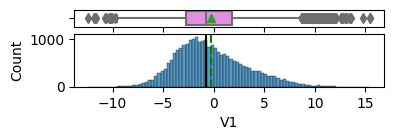

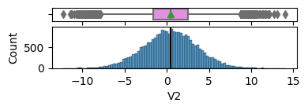

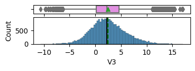

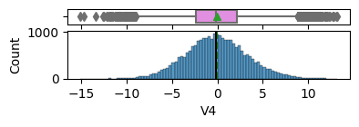

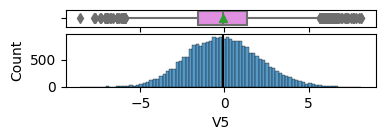

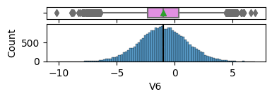

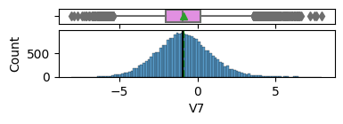

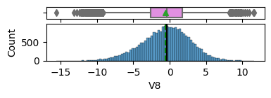

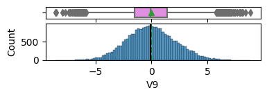

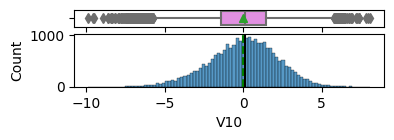

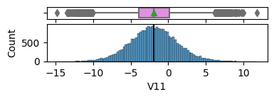

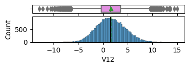

[29 more figures not shown]

```python
for feature in df_total.columns:
    histogram_boxplot(df_total, feature, figsize=(4, 1), kde=False, bins=None)
```

- It seems all features shows a normal distribution.

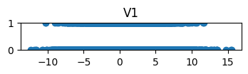

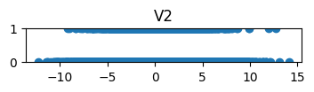

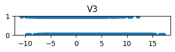

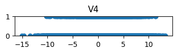

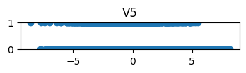

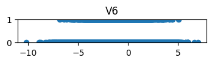

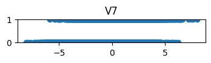

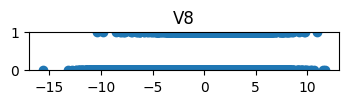

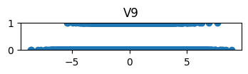

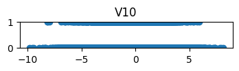

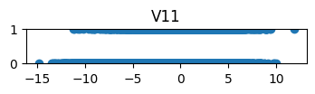

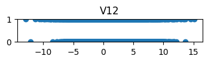

[29 more figures not shown]

```python
for feature in df_total.columns:
    plt.figure(figsize=(4, 0.5))
    plt.scatter(df_total[feature], df_total['Target'])
    plt.title(feature)
    plt.ylim(0, 1)
    plt.show()
```

- As we can see in the previous plots that there is no clear indication of a specific range of failure in any of the features. This means that failure is results through a combination of features, not by any one individually.

### Plotting all the features at one go

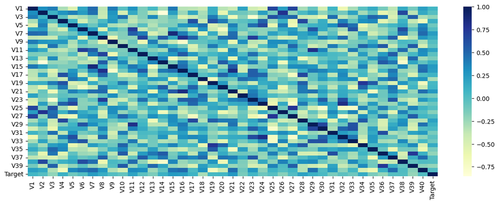

```python
fig, ax = plt.subplots(figsize=(15,5))
sns.heatmap(data=df_total.corr(), annot=False, cmap='YlGnBu');
```

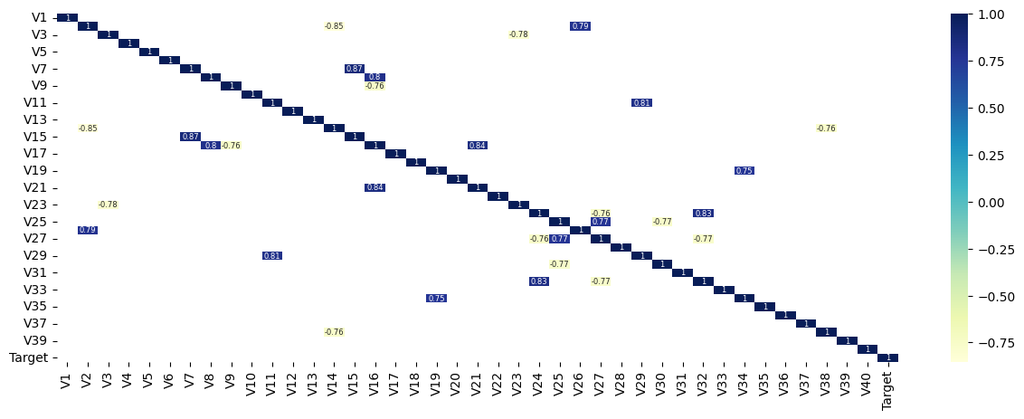

```python
import matplotlib.pyplot as plt
import seaborn as sns

correlation_matrix = df_total.corr()

# Show all correlation greater than 0.75 or lower than -0.75
mask = (correlation_matrix > 0.75) | (correlation_matrix < -0.75)

fig, ax = plt.subplots(figsize=(15, 5))

sns.heatmap(data=correlation_matrix[mask], annot=True, cmap='YlGnBu',annot_kws={"size":6})

plt.show()
```

- There are 8 features with high correlation (> 0.75);
- There are 7 features with inverse high correlation (<-0.75)

```python
df_total['Target'].value_counts(normalize = True)
```

```
0   0.944
1   0.056
Name: Target, dtype: float64
```

```python
df_train['Target'].value_counts(normalize = True)
```

```
0   0.945
1   0.056
Name: Target, dtype: float64
```

```python
df_test['Target'].value_counts(normalize = True)
```

```
0   0.944
1   0.056
Name: Target, dtype: float64
```

- Only 5.6% of observation is target=1 that means "failure". Definitely needs to use the parameter stratify while splitting the data.

## Data Pre-processing

- Dataframe is already splited in the 80:20 ratio (train and test).
- So, we will split train set into train and validation in the 75:25 ratio.

```python
# Splitting data into training, validation and test set:

X1 = df_train.drop(["Target"], axis=1)
y1 = df_train["Target"]

X_test = df_test.drop(columns=["Target"], axis=1)
y_test = df_test["Target"]

# Splitting the train set into train and validation
X_train, X_val, y_train, y_val = train_test_split(X1, y1, test_size=0.25, random_state=1, stratify=y1)

print(X_train.shape, X_val.shape, X_test.shape)
```

```
(15000, 40) (5000, 40) (5000, 40)
```

## Missing value imputation

```python
train_null=df_train.columns[df_train.isnull().any()].tolist()
test_null=df_train.columns[df_train.isnull().any()].tolist()

print("Train set:")
for col in train_null:
    print(f"{col}: {df_train[col].isnull().sum()} missing values")

print("Test set:")
for col in test_null:
    print(f"{col}: {df_test[col].isnull().sum()} missing values")
```

```
Train set:
V1: 18 missing values
V2: 18 missing values
Test set:
V1: 5 missing values
V2: 6 missing values
```

There are few missing values in the dataframe (47), considering a total of 25,000 observations. Therefore, they will not influence our analysis, whether replaced by medians or KNN imputer methods.

```python
imputer = SimpleImputer(strategy="median")
```

```python
# Fit and transform the train data
X_train = pd.DataFrame(imputer.fit_transform(X_train), columns=X_train.columns)

# Transform the validation data
X_val = pd.DataFrame(imputer.transform(X_val), columns=X_train.columns)

# Transform the test data
X_test = pd.DataFrame(imputer.transform(X_test), columns=X_train.columns)
```

```python
# Checking that no column has missing values in train or test sets
print(X_train.isna().sum())
print("-" * 30)
print(X_val.isna().sum())
print("-" * 30)
print(X_test.isna().sum())
```

```
V1     0
V2     0
V3     0
V4     0
V5     0
V6     0
V7     0
V8     0
V9     0
V10    0
V11    0
V12    0
V13    0
V14    0
V15    0
V16    0
V17    0
V18    0
V19    0
V20    0
V21    0
V22    0
V23    0
V24    0
V25    0
V26    0
V27    0
V28    0
V29    0
V30    0
V31    0
V32    0
V33    0
V34    0
V35    0
V36    0
V37    0
V38    0
V39    0
V40    0
```

[output cut: 70 more lines]

```
V27    0
V28    0
V29    0
V30    0
V31    0
V32    0
V33    0
V34    0
V35    0
V36    0
V37    0
V38    0
V39    0
V40    0
dtype: int64
```

- All missing values were replaced.

## Model Building

**What does ReneWind want?**

ReneWind wants to reduce the cost - it can face 3 types of cost here from the most costly to less:

- Cost of inspection < Cost of repair < Cost of replacing.
- The highest cost: False negatives (FN) are real failures where there is no detection by the model. These will result in replacement costs.
- Mid Cost: True positives (TP) are failures correctly predicted by the model. These will result in repairing costs.
- The lowest cost: False positives (FP) are detections where there is no failure. These will result in inspection costs.
- Recall - implies low false negatives, i.e. low chances of predicting "bad" machine as "good" that can result in the higher replacement costs.

### Model evaluation criterion

The nature of predictions made by the classification model will translate as follows:

- True positives (TP) are failures correctly predicted by the model.
- False negatives (FN) are real failures in a generator where there is no detection by model.
- False positives (FP) are failure detections in a generator where there is no failure.

**Which metric to optimize?**

- We need to choose the metric which will ensure that the maximum number of generator failures are predicted correctly by the model.
- We would want Recall to be maximized as greater the Recall, the higher the chances of minimizing false negatives.
- We want to minimize false negatives because if a model predicts that a machine will have no failure when there will be a failure, it will increase the maintenance cost.

```python
# defining a function to compute different metrics to check performance of a classification model built using sklearn
def model_performance_classification_sklearn(model, predictors, target):
    """
    Function to compute different metrics to check classification model performance

    model: classifier
    predictors: independent variables
    target: dependent variable
    """

    # predicting using the independent variables
    pred = model.predict(predictors)

    acc = accuracy_score(target, pred)  # to compute Accuracy
    recall = recall_score(target, pred)  # to compute Recall
    precision = precision_score(target, pred)  # to compute Precision
    f1 = f1_score(target, pred)  # to compute F1-score

    # creating a dataframe of metrics
    df_perf = pd.DataFrame(
        {
            "Accuracy": acc,
            "Recall": recall,
            "Precision": precision,
            "F1": f1

        },
        index=[0],
    )

    return df_perf
```

```python
def confusion_matrix_sklearn(model, predictors, target):
    """
    To plot the confusion_matrix with percentages

    model: classifier
    predictors: independent variables
    target: dependent variable
    """
    y_pred = model.predict(predictors)
    cm = confusion_matrix(target, y_pred)
    labels = np.asarray(
        [
            ["{0:0.0f}".format(item) + "\n{0:.2%}".format(item / cm.flatten().sum())]
            for item in cm.flatten()
        ]
    ).reshape(2, 2)

    plt.figure(figsize=(6, 4))
    sns.heatmap(cm, annot=labels, fmt="")
    plt.ylabel("True label")
    plt.xlabel("Predicted label")
```

### Defining scorer to be used for cross-validation and hyperparameter tuning

- We want to reduce false negatives and will try to maximize "Recall".
- To maximize Recall, we can use Recall as a **scorer** in cross-validation and hyperparameter tuning.

```python
# Type of scoring used to compare parameter combinations
scorer = metrics.make_scorer(metrics.recall_score)
```

### Model Building with Original data

```python
%%time


models = []  # Empty list to store all the models

# Appending models into the list
models.append(("Bagging", BaggingClassifier(random_state=1)))
models.append(("Random forest", RandomForestClassifier(random_state=1)))
models.append(("GBM", GradientBoostingClassifier(random_state=1)))
models.append(("Adaboost", AdaBoostClassifier(random_state=1)))
models.append(("Xgboost", XGBClassifier(random_state=1, eval_metric="logloss")))
models.append(("dtree", DecisionTreeClassifier(random_state=1)))

results1 = []  # Empty list to store all model's CV scores
names = []  # Empty list to store name of the models

# loop through all models to get the mean cross validated score
print("\n" "Cross-Validation performance on training dataset:" "\n")

for name, model in models:
    kfold = StratifiedKFold(
        n_splits=5, shuffle=True, random_state=1
    )  # Setting number of splits equal to 5
    cv_result = cross_val_score(
        estimator=model, X=X_train, y=y_train, scoring = scorer,cv=kfold
    )
    results1.append(cv_result)
    names.append(name)
    print("{}: {}".format(name, cv_result.mean()))

print("\n" "Cross-Validation performance on validation dataset:" "\n")

for name, model in models:
    model.fit(X_train, y_train)
    scores = recall_score(y_val, model.predict(X_val))
    print("{}: {}".format(name, scores))
```

```
Cross-Validation performance on training dataset:

Bagging: 0.7210807301060529
Random forest: 0.7235192266070268
GBM: 0.7066661857008874
Adaboost: 0.6309140754635308
Xgboost: 0.7956208065796118
dtree: 0.6982829521679532

Cross-Validation performance on validation dataset:

Bagging: 0.7302158273381295
Random forest: 0.7266187050359713
GBM: 0.7230215827338129
Adaboost: 0.6762589928057554
Xgboost: 0.8201438848920863
dtree: 0.7050359712230215
CPU times: user 6min 57s, sys: 440 ms, total: 6min 57s
Wall time: 6min 13s
```

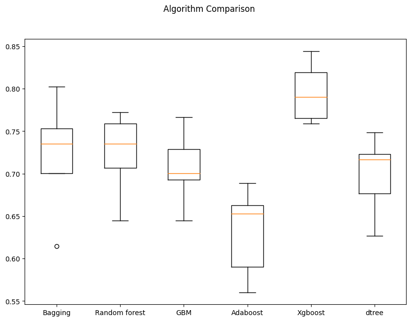

```python
# Plotting boxplots for CV scores of all models defined above
fig = plt.figure(figsize=(10, 7))

fig.suptitle("Algorithm Comparison")
ax = fig.add_subplot(111)

plt.boxplot(results1)
ax.set_xticklabels(names)

plt.show()
```

### Model Building with Oversampled data

```python
# Synthetic Minority Over Sampling Technique
sm = SMOTE(sampling_strategy=1, k_neighbors=5, random_state=1)
X_train_over, y_train_over = sm.fit_resample(X_train, y_train)
```

```python
%%time


models = []  # Empty list to store all the models

# Appending models into the list
models.append(("Bagging", BaggingClassifier(random_state=1)))
models.append(("Random forest", RandomForestClassifier(random_state=1)))
models.append(("GBM", GradientBoostingClassifier(random_state=1)))
models.append(("Adaboost", AdaBoostClassifier(random_state=1)))
models.append(("Xgboost", XGBClassifier(random_state=1, eval_metric="logloss")))
models.append(("dtree", DecisionTreeClassifier(random_state=1)))

results2 = []  # Empty list to store all model's CV scores
names = []  # Empty list to store name of the models

# loop through all models to get the mean cross validated score
print("\n" "Cross-Validation performance on training dataset (Oversampled):" "\n")

for name, model in models:
    kfold = StratifiedKFold(
        n_splits=5, shuffle=True, random_state=1
    )  # Setting number of splits equal to 5
    cv_result2 = cross_val_score(
        estimator=model, X=X_train_over, y=y_train_over, scoring = scorer,cv=kfold
    )
    results2.append(cv_result2)
    names.append(name)
    print("{}: {}".format(name, cv_result2.mean()))

print("\n" "Cross-Validation performance on validation dataset (Oversampled):" "\n")

for name, model in models:
    model.fit(X_train_over, y_train_over)
    scores = recall_score(y_val, model.predict(X_val))
    print("{}: {}".format(name, scores))
```

```
Cross-Validation performance on training dataset (Oversampled):

Bagging: 0.9762141471581656
Random forest: 0.9839075260047615
GBM: 0.9256068151319724
Adaboost: 0.8978689011775473
Xgboost: 0.989554053559209
dtree: 0.9720494245534969

Cross-Validation performance on validation dataset (Oversampled):

Bagging: 0.8345323741007195
Random forest: 0.8489208633093526
GBM: 0.8776978417266187
Adaboost: 0.8561151079136691
Xgboost: 0.8669064748201439
dtree: 0.7769784172661871
CPU times: user 12min 34s, sys: 769 ms, total: 12min 35s
Wall time: 10min 53s
```

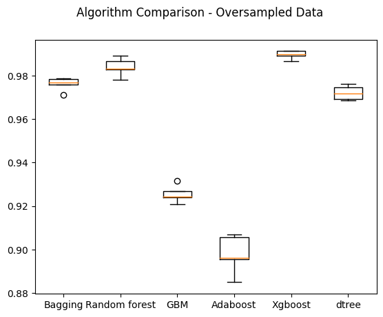

```python
# Plotting boxplots for CV scores of all models defined above
fig = plt.figure()

fig.suptitle("Algorithm Comparison - Oversampled Data")
ax = fig.add_subplot(111)

plt.boxplot(results2)
ax.set_xticklabels(names)

plt.show()
```

- The models with oversampled data performed better than original data, however, they present overfitting.
- The top tree cross-validated recall scores in order are XGboost, Random Forest and Bagging.

### Model Building with Undersampled data

```python
# Random undersampler for under sampling the data
rus = RandomUnderSampler(random_state=1, sampling_strategy=1)
X_train_un, y_train_un = rus.fit_resample(X_train, y_train)
```

```python
%%time


models = []  # Empty list to store all the models

# Appending models into the list
models.append(("Bagging", BaggingClassifier(random_state=1)))
models.append(("Random forest", RandomForestClassifier(random_state=1)))
models.append(("GBM", GradientBoostingClassifier(random_state=1)))
models.append(("Adaboost", AdaBoostClassifier(random_state=1)))
models.append(("Xgboost", XGBClassifier(random_state=1, eval_metric="logloss")))
models.append(("dtree", DecisionTreeClassifier(random_state=1)))

results3 = []  # Empty list to store all model's CV scores
names = []  # Empty list to store name of the models

# loop through all models to get the mean cross validated score
print("\n" "Cross-Validation performance on training dataset (Undersampled):" "\n")

for name, model in models:
    kfold = StratifiedKFold(
        n_splits=5, shuffle=True, random_state=1
    )  # Setting number of splits equal to 5
    cv_result3 = cross_val_score(
        estimator=model, X=X_train_un, y=y_train_un, scoring = scorer,cv=kfold
    )
    results3.append(cv_result3)
    names.append(name)
    print("{}: {}".format(name, cv_result3.mean()))

print("\n" "Cross-Validation performance on validation dataset (Undersampled):" "\n")

for name, model in models:
    model.fit(X_train_un, y_train_un)
    scores = recall_score(y_val, model.predict(X_val))
    print("{}: {}".format(name, scores))
```

```
Cross-Validation performance on training dataset (Undersampled):

Bagging: 0.8641945025611427
Random forest: 0.9038669648654498
GBM: 0.8990621167303946
Adaboost: 0.8666113556020489
Xgboost: 0.9074742082100858
dtree: 0.8617776495202367

Cross-Validation performance on validation dataset (Undersampled):

Bagging: 0.8705035971223022
Random forest: 0.8920863309352518
GBM: 0.8884892086330936
Adaboost: 0.8489208633093526
Xgboost: 0.9028776978417267
dtree: 0.841726618705036
CPU times: user 35.9 s, sys: 75.5 ms, total: 36 s
Wall time: 31.6 s
```

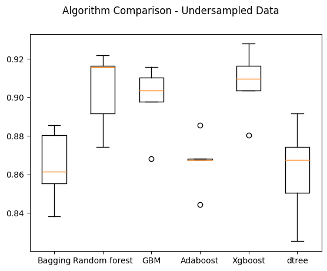

```python
# Plotting boxplots for CV scores of all models defined above
fig = plt.figure()

fig.suptitle("Algorithm Comparison - Undersampled Data")
ax = fig.add_subplot(111)

plt.boxplot(results3)
ax.set_xticklabels(names)

plt.show()
```

- The top tree cross-validated recall scores models in order are XGboost, Random Forest and GBM. No presences of overfitting.

### Comparison (Oversampled and Undersampled data)

```python
print('Nominal Values')
print('X_train:',X_train.shape)
print('y_train:',y_train.shape)
print("Target=1: {}".format(sum(y_train == 1)))
print("Target=0: {} \n".format(sum(y_train == 0)))

print('After Oversampling')
print('X_train_over:',X_train_over.shape)
print('y_train_over:',y_train_over.shape)
print("Target=1: {}".format(sum(y_train_over == 1)))
print("Target=0: {} \n".format(sum(y_train_over == 0)))

print('After Undersampling')
print('X_train_un:',X_train_un.shape)
print('y_train_un:',y_train_un.shape)
print("Target=1: {}".format(sum(y_train_un == 1)))
print("Target=0: {} \n".format(sum(y_train_un == 0)))
```

```
Nominal Values
X_train: (15000, 40)
y_train: (15000,)
Target=1: 832
Target=0: 14168

After Oversampling
X_train_over: (28336, 40)
y_train_over: (28336,)
Target=1: 14168
Target=0: 14168

After Undersampling
X_train_un: (1664, 40)
y_train_un: (1664,)
Target=1: 832
Target=0: 832
```

- Checking if oversampling and undersampling were succeed.
- Oversampling is ok, increasing the amount of target=1 in order to match with target = 0.
- Undersampling is ok, decreasing the amount of target=0 in order to match with target = 1.

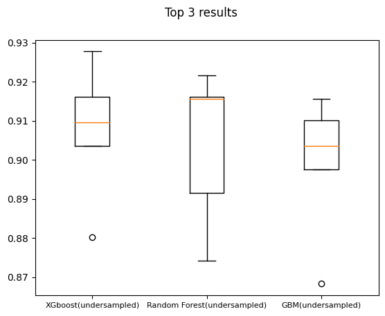

```python
data_to_plot = [results3[4], results3[1], results3[2]]

fig = plt.figure()
fig.suptitle("Top 3 results")
ax = fig.add_subplot(111)

ax.boxplot(data_to_plot)
ax.set_xticklabels(["XGboost(undersampled)", "Random Forest(undersampled)", "GBM(undersampled)"],fontsize=8)

plt.show()
```

- The 3 best performing models among all 18 the models built previously:
  1. XG Boosting in the undersampled data;
  2. Random Forest in the undersampled data;
  3. Gradient Boosting in the undersampled data.

## HyperparameterTuning

### Sample Parameter Grids

**Hyperparameter tuning can take a long time to run, so to avoid that time complexity - you can use the following grids, wherever required.**

- For Gradient Boosting:

param_grid = { "n_estimators": np.arange(100,150,25), "learning_rate": [0.2, 0.05, 1], "subsample":[0.5,0.7], "max_features":[0.5,0.7] }

- For Adaboost:

param_grid = { "n_estimators": [100, 150, 200], "learning_rate": [0.2, 0.05], "base_estimator": [DecisionTreeClassifier(max_depth=1, random_state=1), DecisionTreeClassifier(max_depth=2, random_state=1), DecisionTreeClassifier(max_depth=3, random_state=1), ] }

- For Bagging Classifier:

param_grid = { 'max_samples': [0.8,0.9,1], 'max_features': [0.7,0.8,0.9], 'n_estimators' : [30,50,70], }

- For Random Forest:

param_grid = { "n_estimators": [200,250,300], "min_samples_leaf": np.arange(1, 4), "max_features": [np.arange(0.3, 0.6, 0.1),'sqrt'], "max_samples": np.arange(0.4, 0.7, 0.1) }

- For Decision Trees:

param_grid = { 'max_depth': np.arange(2,6), 'min_samples_leaf': [1, 4, 7], 'max_leaf_nodes' : [10, 15], 'min_impurity_decrease': [0.0001,0.001] }

- For Logistic Regression:

param_grid = {'C': np.arange(0.1,1.1,0.1)}

- For XGBoost:

param_grid={ 'n_estimators': [150, 200, 250], 'scale_pos_weight': [5,10], 'learning_rate': [0.1,0.2], 'gamma': [0,3,5], 'subsample': [0.8,0.9] }

```python
# Type of scoring used to compare parameter combinations
scorer = metrics.make_scorer(metrics.recall_score)
```

### 1 - Sample tuning method for XG Boosting in the undersampled data

```python
%%time

# defining model
Model = XGBClassifier(random_state=1)

# Parameter grid to pass in RandomSearchCV
param_grid={ 'n_estimators': [150, 200, 250], 'scale_pos_weight': [5,10], 'learning_rate': [0.1,0.2], 'gamma': [0,3,5], 'subsample': [0.8,0.9] }

#Calling RandomizedSearchCV
randomized_cv = RandomizedSearchCV(estimator=Model, param_distributions=param_grid, n_iter=10, n_jobs = -1, scoring=scorer, cv=5, random_state=1)

#Fitting parameters in RandomizedSearchCV
randomized_cv.fit(X_train_un,y_train_un)

# Set the classifier to the best combination of parameters
best_params_un=randomized_cv.best_params_
XGB_tuned_un = XGBClassifier(**best_params_un)

# Fit the best algorithm to the data.
XGB_tuned_un.fit(X_train_un, y_train_un)

# Checking recall score on train, validation and test set
XGB_tuned_un_train=recall_score(y_train, XGB_tuned_un.predict(X_train))
XGB_tuned_un_val=recall_score(y_val, XGB_tuned_un.predict(X_val))

print("Hyperparameter Tuning (XG Boosting - Undersampled)")
print("Recall on train set:",XGB_tuned_un_train)
print("Recall on validation set:",XGB_tuned_un_val)
print("")
```

```
Hyperparameter Tuning (XG Boosting - Undersampled)
Recall on train set: 1.0
Recall on validation set: 0.9136690647482014

CPU times: user 15.8 s, sys: 304 ms, total: 16.1 s
Wall time: 1min 59s
```

### 2 - Sample tuning method for Random Forest in the undersampled data

```python
%%time

# defining model
Model = RandomForestClassifier(random_state=1)

# Parameter grid to pass in RandomSearchCV
param_grid = { "n_estimators": [200,250,300], "min_samples_leaf": np.arange(1, 4), "max_features": [np.arange(0.3, 0.6, 0.1),'sqrt'], "max_samples": np.arange(0.4, 0.7, 0.1) }

#Calling RandomizedSearchCV
randomized_cv = RandomizedSearchCV(estimator=Model, param_distributions=param_grid, n_iter=10, n_jobs = -1, scoring=scorer, cv=5, random_state=1)

#Fitting parameters in RandomizedSearchCV
randomized_cv.fit(X_train_un,y_train_un)

# Set the classifier to the best combination of parameters
best_params_un=randomized_cv.best_params_
RF_tuned_un = RandomForestClassifier(**best_params_un)

# Fit the best algorithm to the data.
RF_tuned_un.fit(X_train_un, y_train_un)

# Checking recall score on train, validation and test set
RF_tuned_un_train=recall_score(y_train, RF_tuned_un.predict(X_train))
RF_tuned_un_val=recall_score(y_val, RF_tuned_un.predict(X_val))

print("Hyperparameter Tuning (Random Forest - Undersampled)")
print("Recall on train set:",RF_tuned_un_train)
print("Recall on validation set:",RF_tuned_un_val)
print("")
```

```
Hyperparameter Tuning (Random Forest - Undersampled)
Recall on train set: 0.9759615384615384
Recall on validation set: 0.8884892086330936

CPU times: user 4.4 s, sys: 109 ms, total: 4.51 s
Wall time: 45.2 s
```

- The tuned model showed overfitting in the training set and it didn't demonstrated significant improvements in the validation set.

### 3 - Sample tuning method for Gradient Boosting in the undersampled data.

```python
%%time

# defining model
Model = GradientBoostingClassifier(random_state=1)

# Parameter grid to pass in RandomSearchCV
param_grid = { "n_estimators": np.arange(100,150,25), "learning_rate": [0.2, 0.05, 1], "subsample":[0.5,0.7], "max_features":[0.5,0.7] }

#Calling RandomizedSearchCV
randomized_cv = RandomizedSearchCV(estimator=Model, param_distributions=param_grid, n_iter=10, n_jobs = -1, scoring=scorer, cv=5, random_state=1)

#Fitting parameters in RandomizedSearchCV
randomized_cv.fit(X_train_un,y_train_un)

# Set the classifier to the best combination of parameters
best_params_un=randomized_cv.best_params_
Gradient_tuned_un = GradientBoostingClassifier(**best_params_un)

# Fit the best algorithm to the data.
Gradient_tuned_un.fit(X_train_un, y_train_un)

# Checking recall score on train, validation and test set
Gradient_tuned_un_train=recall_score(y_train, Gradient_tuned_un.predict(X_train))
Gradient_tuned_un_val=recall_score(y_val, Gradient_tuned_un.predict(X_val))

print("Hyperparameter Tuning (Gradient Boosting - Undersampled)")
print("Recall on train set:",Gradient_tuned_un_train)
print("Recall on validation set:",Gradient_tuned_un_val)
print("")
```

```
Hyperparameter Tuning (Gradient Boosting - Undersampled)
Recall on train set: 0.9771634615384616
Recall on validation set: 0.8884892086330936

CPU times: user 2.4 s, sys: 68.4 ms, total: 2.47 s
Wall time: 37.3 s
```

- The tuned model showed overfitting in the training set and it didn't demonstrated significant improvements in the validation set.

## Model performance comparison and choosing the final model

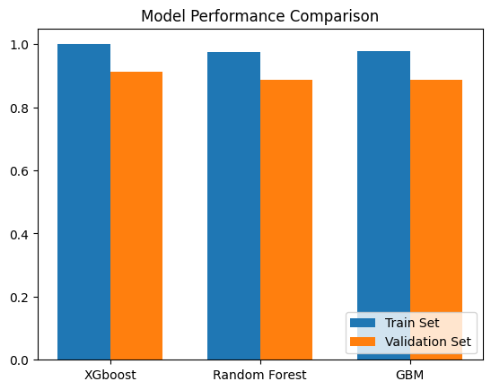

```python
import matplotlib.pyplot as plt
import numpy as np

tuned_train = [XGB_tuned_un_train, RF_tuned_un_train, Gradient_tuned_un_train]
tuned_val = [XGB_tuned_un_val, RF_tuned_un_val, Gradient_tuned_un_val]
tuned_x = ["XGboost", "Random Forest", "GBM"]

bar_width = 0.35
index = np.arange(3)

fig, ax = plt.subplots()

train_bars = ax.bar(index, tuned_train, bar_width, label='Train Set')
val_bars = ax.bar(index + bar_width, tuned_val, bar_width, label='Validation Set')

ax.set_title('Model Performance Comparison')
ax.set_xticks(index + bar_width / 2)
ax.set_xticklabels(tuned_x)
ax.legend()
ax.legend(loc='lower right')

plt.show()
```

```python
from tabulate import tabulate

data = {"Tuned - Undersampled Data": tuned_x, "Training Set": tuned_train, "Validation Set": tuned_val}
df = pd.DataFrame(data)

table = tabulate(df, headers='keys', tablefmt='pretty', showindex=False)
print(table)
```

```
+---------------------------+--------------------+--------------------+
| Tuned - Undersampled Data |    Training Set    |   Validation Set   |
+---------------------------+--------------------+--------------------+
|          XGboost          |        1.0         | 0.9136690647482014 |
|       Random Forest       | 0.9759615384615384 | 0.8884892086330936 |
|            GBM            | 0.9771634615384616 | 0.8884892086330936 |
+---------------------------+--------------------+--------------------+
```

```python
gbm_grid_test = model_performance_classification_sklearn(XGB_tuned_un, X_train, y_train)
print("XB Boosting Train Performance (undersampled):")
gbm_grid_test
```

```
XB Boosting Train Performance (undersampled):
```

|  | Accuracy | Recall | Precision | F1 |
| --- | --- | --- | --- | --- |
| 0 | 0.883 | 1.000 | 0.321 | 0.486 |

```python
gbm_grid_test = model_performance_classification_sklearn(XGB_tuned_un, X_val, y_val)
print("XB Boosting Validation Performance (undersampled):")
gbm_grid_test
```

```
XB Boosting Validation Performance (undersampled):
```

|  | Accuracy | Recall | Precision | F1 |
| --- | --- | --- | --- | --- |
| 0 | 0.866 | 0.914 | 0.283 | 0.432 |

- The overall scores are slightly better with hyperparameter tuning, despite with some overfitting in the training set.
- The XGboost model (undersampled data) using Randomized Search CV is giving the best validation recall of 0.91.